# Bike Sharing Program

## by Salman Mostafa

## Preliminary Wrangling

> The dataset contains data about individual bike rides in Los Angeles(LA) and The City of Philadelphia(PA) from Jan, 2020 to Sept, 2020. The dataset is collected from a bike sharing program in both cities. The collected data from trips in LA and PA has the same structure since the cities partner with Bicycle Transit Systems.

> For more information about the data and the attributes, please visit the following URLs:
> - Los Angeles: https://bikeshare.metro.net/about/data/
> - Philadelphia: https://www.rideindego.com/about/data/

Here is the dataset before segmenting it for the features we need

```python
comb_df.head()
```

|  | trip_id | duration | start_time | end_time | start_station | start_lat | start_lon | end_station | end_lat | end_lon | bike_id | plan_duration | trip_route_category | passholder_type | bike_type | quarter | city | Station_ID | start_station_name |
| --- | --- | --- | --- | --- | --- | --- | --- | --- | --- | --- | --- | --- | --- | --- | --- | --- | --- | --- | --- |
| 0 | 134867493 | 25 | 1/1/2020 0:16 | 1/1/2020 0:41 | 3063 | 34.048038 | -118.253738 | 4491 | 34.047440 | -118.247940 | 18419 | 30 | One Way | Monthly Pass | electric | q1 | LA | 3063 | Pershing Square |
| 1 | 134876196 | 17 | 1/1/2020 7:07 | 1/1/2020 7:24 | 3063 | 34.048038 | -118.253738 | 3066 | 34.063389 | -118.236160 | 6012 | 1 | One Way | One Day Pass | standard | q1 | LA | 3063 | Pershing Square |
| 2 | 134876193 | 13 | 1/1/2020 7:11 | 1/1/2020 7:24 | 3063 | 34.048038 | -118.253738 | 3066 | 34.063389 | -118.236160 | 20029 | 1 | One Way | Walk-up | standard | q1 | LA | 3063 | Pershing Square |
| 3 | 134882296 | 14 | 1/1/2020 11:50 | 1/1/2020 12:04 | 3063 | 34.048038 | -118.253738 | 4220 | 34.074829 | -118.258728 | 5847 | 30 | One Way | Monthly Pass | standard | q1 | LA | 3063 | Pershing Square |
| 4 | 134882295 | 14 | 1/1/2020 11:50 | 1/1/2020 12:04 | 3063 | 34.048038 | -118.253738 | 4220 | 34.074829 | -118.258728 | 18926 | 30 | One Way | Monthly Pass | electric | q1 | LA | 3063 | Pershing Square |

## Questions to explore:

- What percentage are one way and round trip?
- Which station individuals usually start at?
- What is the most common ride duration?
- What is the most common type of pass purchased?
- What is the most common type of bike borrowed?
- How did COVID-19 affect the patterns in the data (trip duration, and type/number of passes, most common type of bike)
- How do these patterns compare between LA and PA?

**The columns we are interested in are:**

```
- duration
- start_station_name
- plan_duration (for context)
- trip_route_category
- passholder_type
- quarter
- city
- bike_type
```

We will keep these columns and drop the rest

Here is the dataset with the features we are interested in

```python
columns_of_interest = ['duration', 'start_station_name', 'plan_duration', 'trip_route_category', 'passholder_type', 'quarter', 'city', 'bike_type']

for column in comb_df.columns:
    if not column in columns_of_interest:
        comb_df.drop(column, axis=1, inplace=True)
comb_df.head()
```

|  | duration | plan_duration | trip_route_category | passholder_type | bike_type | quarter | city | start_station_name |
| --- | --- | --- | --- | --- | --- | --- | --- | --- |
| 0 | 25 | 30 | One Way | Monthly Pass | electric | q1 | LA | Pershing Square |
| 1 | 17 | 1 | One Way | One Day Pass | standard | q1 | LA | Pershing Square |
| 2 | 13 | 1 | One Way | Walk-up | standard | q1 | LA | Pershing Square |
| 3 | 14 | 30 | One Way | Monthly Pass | standard | q1 | LA | Pershing Square |
| 4 | 14 | 30 | One Way | Monthly Pass | electric | q1 | LA | Pershing Square |

### What is the structure of your dataset?

> 739826 instances and 8 attributes

### What is/are the main feature(s) of interest in your dataset?

> - duration
> - trip_route_category
> - passholder_type
> - bike_type
> - start_station_name

### What features in the dataset do you think will help support your investigation into your feature(s) of interest?

> - quarter
> - city
> - plan_duration (for context)

## Univariate Exploration

Ride Duration

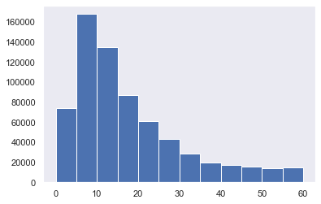

```python
bins = np.arange(0, 65, 5)
comb_df['duration'].hist(bins=bins, grid=False);
```

Ride duration is right-skewed and most of the rides are around 5-10 mins.

Now, let's take a look at the trip route category distribution

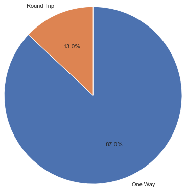

```python
wedges = comb_df['trip_route_category'].value_counts()/len(comb_df)
labels = 'One Way', 'Round Trip'
plt.pie(wedges, autopct='%1.1f%%', labels =labels, startangle=90,counterclock =False, radius= 2);
```

Most of the rides are one way, which means they start at one station and end at another

Plan types

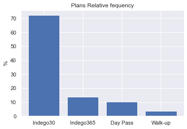

```python
series = comb_df['passholder_type'].value_counts() / len(comb_df)
series_labels = comb_df['plan_duration'].value_counts()
unique_plans = len(comb_df['passholder_type'].unique())+1 #dynamic value for index
indx = np.arange(1,unique_plans)
plt.bar(indx, series*100)
plt.ylabel('%')
plt.title('Plans Relative fequency')
plt.xticks(indx, series.index);
```

The Indego30 is the most popular plan by a big margin

We are looking at bike types next

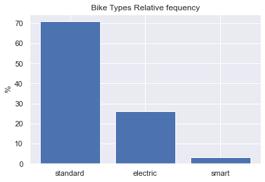

```python
series = comb_df['bike_type'].value_counts() / len(comb_df)
series_labels = comb_df['bike_type'].value_counts()
unique_bike_types = len(comb_df['bike_type'].unique())+1 #dynamic value for index
indx = np.arange(1,unique_bike_types)
plt.bar(indx, series*100)
plt.ylabel('%')
plt.title('Bike Types Relative fequency')
plt.xticks(indx, series.index);
```

As we can see, most of the bikes used are standard bikes. I'm curious to see how these percentages compare before and after COVID-19. We'll explore that in the bivariate section

Let's check the percentage of rides in each state next

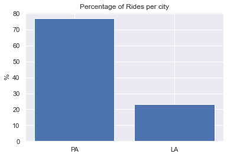

```python
series = comb_df['city'].value_counts() / len(comb_df)
series_labels = comb_df['city'].value_counts()
indx = np.arange(1,3)
plt.bar(indx, series*100)
plt.ylabel('%')
plt.title('Percentage of Rides per city')
plt.xticks(indx, series.index);
```

Let's check the percentage of rides in each quarter

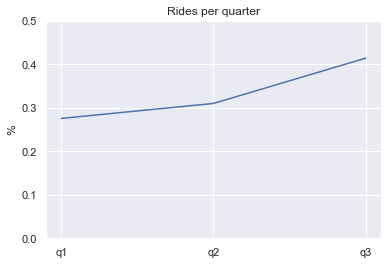

```python
#Number of bike rides in each quarter

data = comb_df['quarter'].value_counts()
quarters = []
for i in range(2,-1,-1):
    quarters.append(data[i]/len(comb_df))

names = ['q1','q2','q3']

plt.plot(names, quarters);
plt.ylim([0,0.5]);
plt.title("Rides per quarter")
plt.ylabel("%");
```

The number of rides increased from q1 to q3. There is probably a correlation between the increase and COVID-19 since people wanted something to do outside the longer the quarantine lasted

### Discuss the distribution(s) of your variable(s) of interest. Were there any unusual points? Did you need to perform any transformations?

> The variable distributions are discussed above. Yes, I did need to transform the trip duration and passholder_type. The most interesting finding her is that people in Philadelphia seem to be more active on bikes than people in LA according to this dataset. In addition, I saw that the number of rides increased from q1 to q3; I thought that was interesting too.

### Of the features you investigated, were there any unusual distributions? Did you perform any operations on the data to tidy, adjust, or change the form of the data? If so, why did you do this?

> The trip duration contained many outliers and was right-skewed. Using some research about the plans, summary statistics and histogram, I decided to exclude durations above 60 mins. For the passholder_type, I excluded two pass types because they represented a very small percentage of the data and combined multiple pass types into the ones currently available for purchase on the bike sharing website here: https://www.rideindego.com/buy-a-pass/#/.

## Bivariate Exploration

In this section, we will be mostly looking at the above attributes but segmented by q1 in one segment (representing the time period before COVID-19) and q2 & q3 in another segment (representing the time period during/after COVID-19). We will follow the same order for the ease of comparison

Let's start with duration

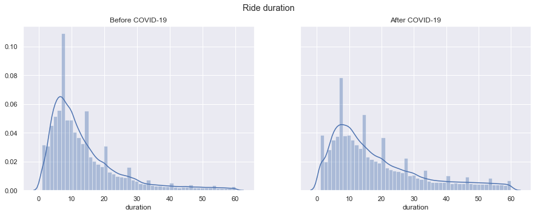

```python
#code concept from piRSquared and Mark Ginsburg at https://stackoverflow.com/questions/45069828/how-to-plot-2-histograms-side-by-side?rq=1
fig, axes = plt.subplots(1,2, figsize =(15,5), sharey =True)
plt.suptitle("Ride duration")

sb.distplot(before_covid_df['duration'], ax=axes[0])

axes[0].set_title("Before COVID-19")

sb.distplot(after_covid_df['duration'], ax=axes[1])

axes[1].set_title("After COVID-19");
```

The distribution of ride duration does not change before and after COVID-19 at around 8 minutes and is right_skewed

Let's look at Plans purchased before and after COVID-19

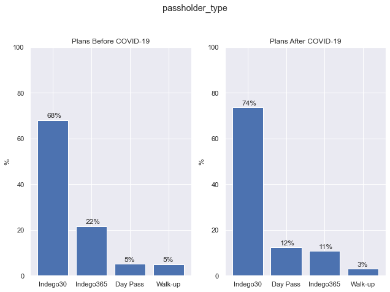

```python
#plot bar charts for passholder type
bar_subplots("passholder_type", df1, df2, 'passholder_type', "Plans Before COVID-19", "Plans After COVID-19")
```

Let's look at Trip_route before and after COVID-19

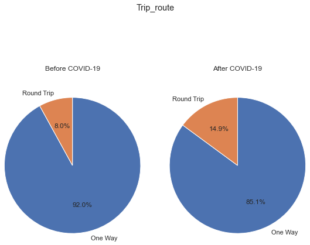

```python
labels = 'One Way', 'Round Trip'
pie_subplots("Trip_route", df1, df2, 'trip_route_category',"Before COVID-19","After COVID-19", labels)
```

Interesting...more people are doing round trips during/after COVID-19 than they used to.

Lastly, let's take a look at bike types before and after COVID-19

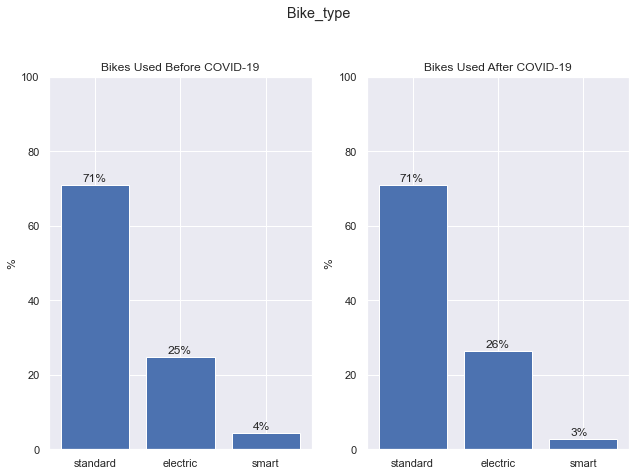

```python
bar_subplots("Bike_type", df1, df2, 'bike_type', "Bikes Used Before COVID-19", "Bikes Used After COVID-19")
```

There is almost no change here except that smart bikes are used less and electric bikes are used more by 1% after COVID-19

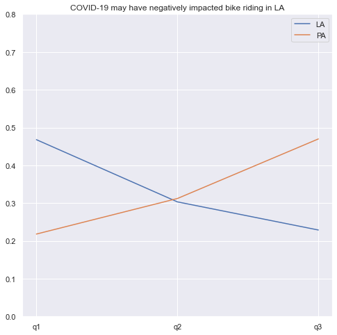

```python
plt.figure(figsize=(8,8))
LA_df = comb_df[comb_df['city']=='LA']
PA_df = comb_df[comb_df['city']=='PA']
plt.plot(LA_df['quarter'].value_counts().sort_index()/len(LA_df), label = 'LA')
plt.plot(PA_df['quarter'].value_counts().sort_index()/len(PA_df), label = 'PA')
plt.ylim([0,0.8])
plt.legend();
plt.title('COVID-19 may have negatively impacted bike riding in LA');
```

This is Interesting! The number of bike rides in LA decreased during/after COVID-19. This is worth looking more into!

### Talk about some of the relationships you observed in this part of the investigation. How did the feature(s) of interest vary with other features in the dataset?

> When adding the 2020 quarter variable into the relationships, as an indicator of the time periods before and after COVID-19, some of the variables showed some change before and after. In addition, I studied how the number of bike rides changed over time between PA and LA. I found an interesting change

### Did you observe any interesting relationships between the other features (not the main feature(s) of interest)?

> The most interesting finding is that the number of bike rides in LA decreased during/after COVID-19 whereas it increased in PA. Does COVID-19 have a hand in this?

> Yes, One of the noticable changes before and after the quarantine is that about 6% more people are doing round trips during/after COVID-19 than before.

> In addition, Day passes became more popular than Indego365 annual passes after COVID-19. I think this is related to people needing to go outside for the day at the spur of the moment because they are tired of sitting at home.

## Multivariate Exploration

During Bivariate exploration, we found that there is a decresase in the number of rides in LA and There is an increase in PA during the same time period (q1-q3) Let's now look deeper into bike_type and trip_route to try to find out why that's the case.

Let's start by the bikes used in LA

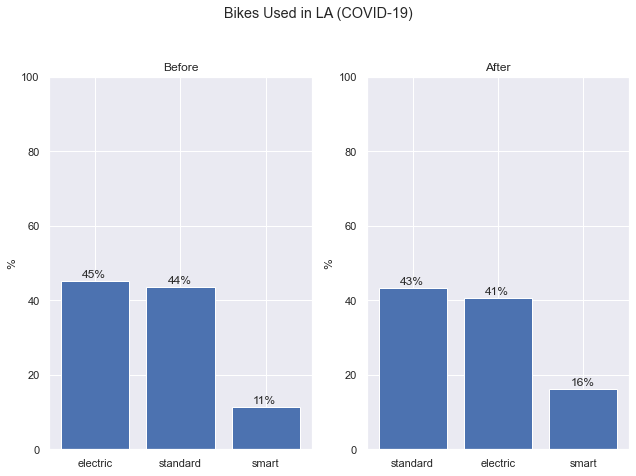

```python
df1 = LA_before_covid_df
df2 = LA_after_covid_df
bar_subplots("Bikes Used in LA (COVID-19)", df1, df2, 'bike_type', "Before", "After")
```

What about Philadelphia?

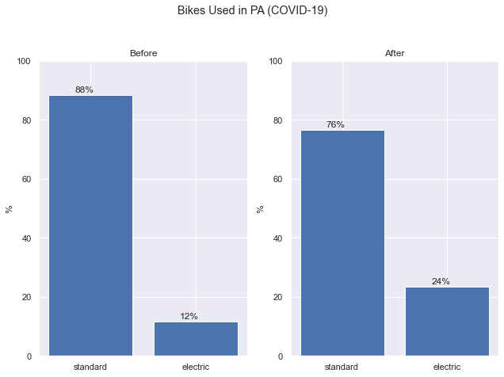

```python
df1 = PA_before_covid_df
df2 = PA_after_covid_df
bar_subplots("Bikes Used in PA (COVID-19)", df1, df2, 'bike_type', "Before", "After")
```

In Philadelphia, that is not the case. The number of electric bikes used doubled

Let's compare the before and after from each city together

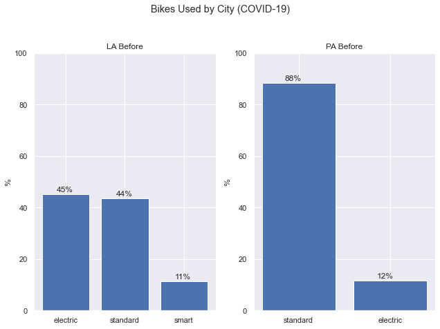

```python
df1 = LA_before_covid_df
df2 = PA_before_covid_df
bar_subplots("Bikes Used by City (COVID-19)", df1, df2, 'bike_type', "LA Before", "PA Before")
```

Okay, a much bigger percentage of people were using the standard bike type in PA. How about after COVID-19?

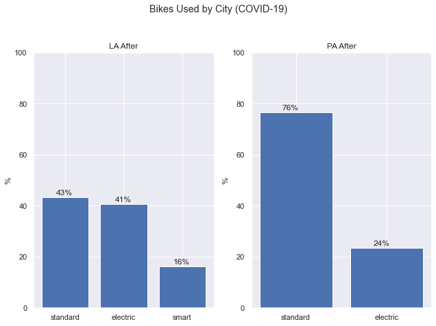

```python
df1 = LA_after_covid_df
df2 = PA_after_covid_df
bar_subplots("Bikes Used by City (COVID-19)", df1, df2, 'bike_type', "LA After", "PA After")
```

Relatively, LA stayed consistent with the type of bikes it prefers, whereas a spike of interest happened in PA towards electric bikes

Let's see how the trip routes compare to make a primary conclusion based on what we have in the dataset.

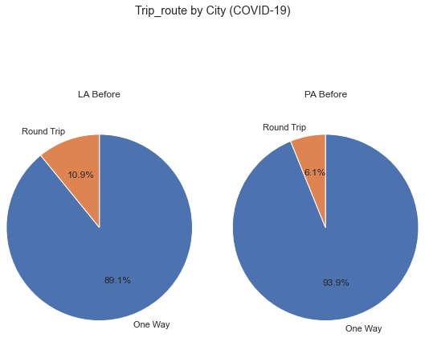

```python
df1 = LA_before_covid_df
df2 = PA_before_covid_df
labels = 'One Way', 'Round Trip'
pie_subplots("Trip_route by City (COVID-19)", df1, df2, 'trip_route_category',"LA Before","PA Before", labels)
```

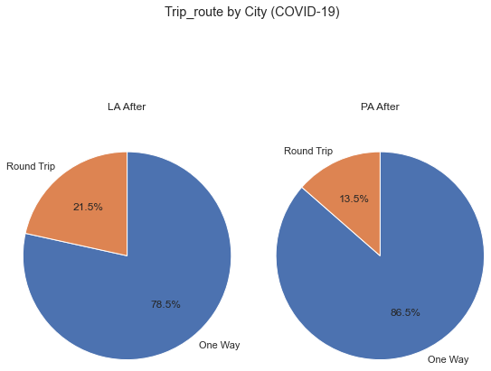

```python
df1 = LA_after_covid_df
df2 = PA_after_covid_df
labels = 'One Way', 'Round Trip'
pie_subplots("Trip_route by City (COVID-19)", df1, df2, 'trip_route_category',"LA After","PA After", labels)
```

Here is what we see in these two plots:

```
- More people do round trips in LA both before and after COVID-19
- The number of round trips increased in both cities
```

### Talk about some of the relationships you observed in this part of the investigation. Were there features that strengthened each other in terms of looking at your feature(s) of interest?

> Adding the city and quarter to the visualizations showed interesting relationships which I discuss above.